# Risk Factor Analysis

## Outcome Variable

**Outcome Variable:** wast_rec90d

## Predictor Variables

**Intervention Variable:** predfeed6

**Adjustment Set:**

- arm
- sex
- month
- brthmon
- W_mage
- meducyrs
- feducyrs
- hhwealth_quart
- hfoodsec
- W_mhtcm
- W_mwtkg
- W_mbmi
- vagbrth
- W_gagebrth
- W_birthwt
- W_birthlen
- W_nrooms
- W_nchldlt5
- W_parity
- impfloor
- impsan
- safeh20
- delta_W_mage
- delta_meducyrs
- delta_feducyrs
- delta_hhwealth_quart
- delta_hfoodsec
- delta_W_mhtcm
- delta_W_mwtkg
- delta_W_mbmi
- delta_vagbrth
- delta_W_gagebrth
- delta_W_birthwt
- delta_W_birthlen
- delta_W_nrooms
- delta_W_nchldlt5
- delta_W_parity
- delta_impfloor
- delta_impsan
- delta_safeh20

## Stratifying Variables

The analysis was stratified on these variable(s):

- agecat
- studyid
- country

## Data Summary

| agecat | studyid | country | predfeed6 | wast_rec90d | n_cell | n |
| --- | --- | --- | --- | --- | --- | --- |
| 0-24 months | EE | PAKISTAN | 1 | 0 | 15 | 34 |
| 0-24 months | EE | PAKISTAN | 1 | 1 | 16 | 34 |
| 0-24 months | EE | PAKISTAN | 0 | 0 | 0 | 34 |
| 0-24 months | EE | PAKISTAN | 0 | 1 | 3 | 34 |
| 0-24 months | GMS-Nepal | NEPAL | 1 | 0 | 192 | 594 |
| 0-24 months | GMS-Nepal | NEPAL | 1 | 1 | 251 | 594 |
| 0-24 months | GMS-Nepal | NEPAL | 0 | 0 | 70 | 594 |
| 0-24 months | GMS-Nepal | NEPAL | 0 | 1 | 81 | 594 |
| 0-24 months | JiVitA-3 | BANGLADESH | 1 | 0 | 2004 | 4526 |
| 0-24 months | JiVitA-3 | BANGLADESH | 1 | 1 | 1506 | 4526 |
| 0-24 months | JiVitA-3 | BANGLADESH | 0 | 0 | 594 | 4526 |
| 0-24 months | JiVitA-3 | BANGLADESH | 0 | 1 | 422 | 4526 |
| 0-24 months | JiVitA-4 | BANGLADESH | 1 | 0 | 986 | 1841 |
| 0-24 months | JiVitA-4 | BANGLADESH | 1 | 1 | 372 | 1841 |
| 0-24 months | JiVitA-4 | BANGLADESH | 0 | 0 | 349 | 1841 |
| 0-24 months | JiVitA-4 | BANGLADESH | 0 | 1 | 134 | 1841 |
| 0-24 months | LCNI-5 | MALAWI | 1 | 0 | 5 | 34 |
| 0-24 months | LCNI-5 | MALAWI | 1 | 1 | 2 | 34 |
| 0-24 months | LCNI-5 | MALAWI | 0 | 0 | 22 | 34 |
| 0-24 months | LCNI-5 | MALAWI | 0 | 1 | 5 | 34 |
| 0-24 months | MAL-ED | BANGLADESH | 1 | 0 | 15 | 114 |
| 0-24 months | MAL-ED | BANGLADESH | 1 | 1 | 30 | 114 |
| 0-24 months | MAL-ED | BANGLADESH | 0 | 0 | 25 | 114 |
| 0-24 months | MAL-ED | BANGLADESH | 0 | 1 | 44 | 114 |
| 0-24 months | MAL-ED | BRAZIL | 1 | 0 | 1 | 24 |
| 0-24 months | MAL-ED | BRAZIL | 1 | 1 | 1 | 24 |
| 0-24 months | MAL-ED | BRAZIL | 0 | 0 | 5 | 24 |
| 0-24 months | MAL-ED | BRAZIL | 0 | 1 | 17 | 24 |
| 0-24 months | MAL-ED | INDIA | 1 | 0 | 0 | 162 |
| 0-24 months | MAL-ED | INDIA | 1 | 1 | 2 | 162 |

[output cut: 126 more lines]

The following strata were considered:

- agecat: 0-24 months, studyid: EE, country: PAKISTAN
- agecat: 0-24 months, studyid: GMS-Nepal, country: NEPAL
- agecat: 0-24 months, studyid: JiVitA-3, country: BANGLADESH
- agecat: 0-24 months, studyid: JiVitA-4, country: BANGLADESH
- agecat: 0-24 months, studyid: LCNI-5, country: MALAWI
- agecat: 0-24 months, studyid: MAL-ED, country: BANGLADESH
- agecat: 0-24 months, studyid: MAL-ED, country: BRAZIL
- agecat: 0-24 months, studyid: MAL-ED, country: INDIA
- agecat: 0-24 months, studyid: MAL-ED, country: NEPAL
- agecat: 0-24 months, studyid: MAL-ED, country: PERU
- agecat: 0-24 months, studyid: MAL-ED, country: SOUTH AFRICA
- agecat: 0-24 months, studyid: MAL-ED, country: TANZANIA, UNITED REPUBLIC OF
- agecat: 0-24 months, studyid: SAS-FoodSuppl, country: INDIA
- agecat: 0-6 months, studyid: EE, country: PAKISTAN
- agecat: 0-6 months, studyid: GMS-Nepal, country: NEPAL
- agecat: 0-6 months, studyid: JiVitA-3, country: BANGLADESH
- agecat: 0-6 months, studyid: JiVitA-4, country: BANGLADESH
- agecat: 0-6 months, studyid: LCNI-5, country: MALAWI
- agecat: 0-6 months, studyid: MAL-ED, country: BANGLADESH
- agecat: 0-6 months, studyid: MAL-ED, country: BRAZIL
- agecat: 0-6 months, studyid: MAL-ED, country: INDIA
- agecat: 0-6 months, studyid: MAL-ED, country: NEPAL
- agecat: 0-6 months, studyid: MAL-ED, country: PERU
- agecat: 0-6 months, studyid: MAL-ED, country: SOUTH AFRICA
- agecat: 0-6 months, studyid: MAL-ED, country: TANZANIA, UNITED REPUBLIC OF
- agecat: 0-6 months, studyid: SAS-FoodSuppl, country: INDIA
- agecat: 6-24 months, studyid: EE, country: PAKISTAN
- agecat: 6-24 months, studyid: GMS-Nepal, country: NEPAL
- agecat: 6-24 months, studyid: JiVitA-3, country: BANGLADESH
- agecat: 6-24 months, studyid: JiVitA-4, country: BANGLADESH
- agecat: 6-24 months, studyid: LCNI-5, country: MALAWI
- agecat: 6-24 months, studyid: MAL-ED, country: BANGLADESH
- agecat: 6-24 months, studyid: MAL-ED, country: BRAZIL
- agecat: 6-24 months, studyid: MAL-ED, country: INDIA
- agecat: 6-24 months, studyid: MAL-ED, country: NEPAL
- agecat: 6-24 months, studyid: MAL-ED, country: PERU
- agecat: 6-24 months, studyid: MAL-ED, country: SOUTH AFRICA
- agecat: 6-24 months, studyid: MAL-ED, country: TANZANIA, UNITED REPUBLIC OF
- agecat: 6-24 months, studyid: SAS-FoodSuppl, country: INDIA

### Dropped Strata

Some strata were dropped due to rare outcomes:

- agecat: 0-24 months, studyid: EE, country: PAKISTAN
- agecat: 0-24 months, studyid: LCNI-5, country: MALAWI
- agecat: 0-24 months, studyid: MAL-ED, country: BRAZIL
- agecat: 0-24 months, studyid: MAL-ED, country: INDIA
- agecat: 0-24 months, studyid: MAL-ED, country: NEPAL
- agecat: 0-24 months, studyid: MAL-ED, country: PERU
- agecat: 0-24 months, studyid: MAL-ED, country: SOUTH AFRICA
- agecat: 0-24 months, studyid: MAL-ED, country: TANZANIA, UNITED REPUBLIC OF
- agecat: 0-24 months, studyid: SAS-FoodSuppl, country: INDIA
- agecat: 0-6 months, studyid: EE, country: PAKISTAN
- agecat: 0-6 months, studyid: LCNI-5, country: MALAWI
- agecat: 0-6 months, studyid: MAL-ED, country: BANGLADESH
- agecat: 0-6 months, studyid: MAL-ED, country: BRAZIL
- agecat: 0-6 months, studyid: MAL-ED, country: INDIA
- agecat: 0-6 months, studyid: MAL-ED, country: NEPAL
- agecat: 0-6 months, studyid: MAL-ED, country: PERU
- agecat: 0-6 months, studyid: MAL-ED, country: SOUTH AFRICA
- agecat: 0-6 months, studyid: MAL-ED, country: TANZANIA, UNITED REPUBLIC OF
- agecat: 0-6 months, studyid: SAS-FoodSuppl, country: INDIA
- agecat: 6-24 months, studyid: EE, country: PAKISTAN
- agecat: 6-24 months, studyid: JiVitA-3, country: BANGLADESH
- agecat: 6-24 months, studyid: LCNI-5, country: MALAWI
- agecat: 6-24 months, studyid: MAL-ED, country: BRAZIL
- agecat: 6-24 months, studyid: MAL-ED, country: INDIA
- agecat: 6-24 months, studyid: MAL-ED, country: NEPAL
- agecat: 6-24 months, studyid: MAL-ED, country: PERU
- agecat: 6-24 months, studyid: MAL-ED, country: SOUTH AFRICA
- agecat: 6-24 months, studyid: MAL-ED, country: TANZANIA, UNITED REPUBLIC OF
- agecat: 6-24 months, studyid: SAS-FoodSuppl, country: INDIA

## Methods Detail

We’re interested in the causal parameters $E[Y_a]$ for all values of $a \in \mathcal{A}$. These parameters represent the mean outcome if, possibly contrary to fact, we intervened to set all units to have $A=a$. Under the randomization and positivity assumptions, these are identified by the statistical parameters $\psi_a=E_W[E_{Y|A,W}(Y|A=a,W)]$. In addition, we’re interested in the mean of $Y$, $E[Y]$ under no intervention (the observed mean). We will estimate these parameters by using SuperLearner to fit the relevant likelihood factors – $E_{Y|A,W}(Y|A=a,W)$ and $p(A=a|W)$, and then updating our likelihood fit using a joint TMLE.

For unadjusted analyses ($W=\{\}$), initial likelihoods were estimated using Lrnr_glm to estimate the simple $E(Y|A)$ and Lrnr_mean to estimate $p(A)$. For adjusted analyses, a small library containing Lrnr_glmnet, Lrnr_xgboost, and Lrnr_mean was used.

Having estimated these parameters, we will then use the delta method to estimate relative risks and attributable risks relative to a prespecified baseline level of $A$.

# Results Detail

## Results Plots

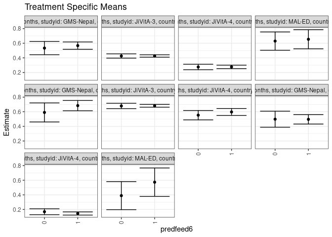

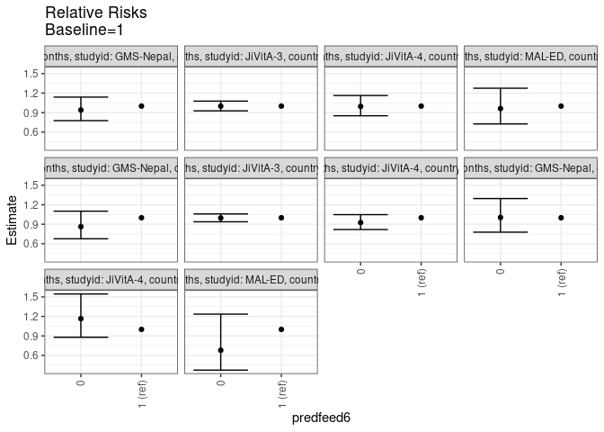

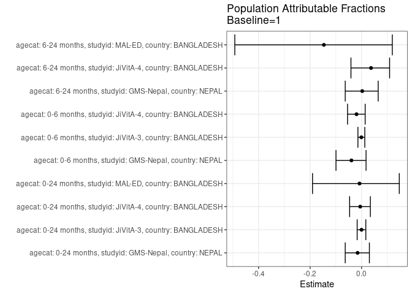

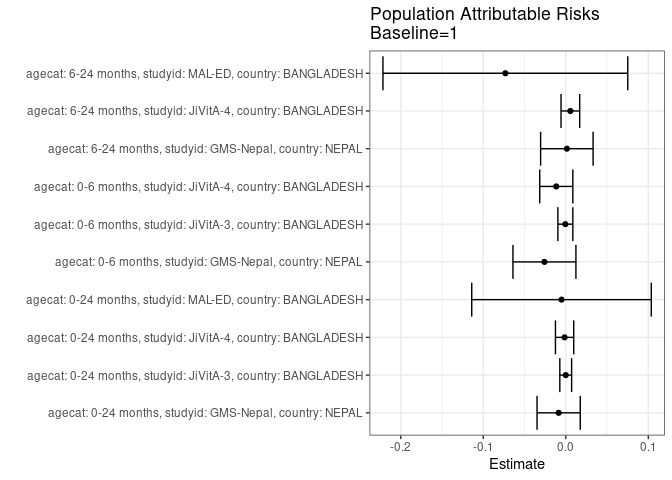

## Results Table

### Parameter: TSM

| agecat | studyid | country | intervention_level | baseline_level | estimate | ci_lower | ci_upper |
| --- | --- | --- | --- | --- | --- | --- | --- |
| 0-24 months | GMS-Nepal | NEPAL | 1 | NA | 0.5675692 | 0.5175354 | 0.6176031 |
| 0-24 months | GMS-Nepal | NEPAL | 0 | NA | 0.5336037 | 0.4428185 | 0.6243888 |
| 0-24 months | JiVitA-3 | BANGLADESH | 1 | NA | 0.4260675 | 0.4100706 | 0.4420644 |
| 0-24 months | JiVitA-3 | BANGLADESH | 0 | NA | 0.4256690 | 0.3968280 | 0.4545099 |
| 0-24 months | JiVitA-4 | BANGLADESH | 1 | NA | 0.2763136 | 0.2523285 | 0.3002988 |
| 0-24 months | JiVitA-4 | BANGLADESH | 0 | NA | 0.2750250 | 0.2370683 | 0.3129818 |
| 0-24 months | MAL-ED | BANGLADESH | 1 | NA | 0.6543254 | 0.5237078 | 0.7849430 |
| 0-24 months | MAL-ED | BANGLADESH | 0 | NA | 0.6296298 | 0.5045577 | 0.7547019 |
| 0-6 months | GMS-Nepal | NEPAL | 1 | NA | 0.6837854 | 0.6131425 | 0.7544283 |
| 0-6 months | GMS-Nepal | NEPAL | 0 | NA | 0.5903424 | 0.4601696 | 0.7205152 |
| 0-6 months | JiVitA-3 | BANGLADESH | 1 | NA | 0.6813242 | 0.6620082 | 0.7006401 |
| 0-6 months | JiVitA-3 | BANGLADESH | 0 | NA | 0.6790575 | 0.6423794 | 0.7157357 |
| 0-6 months | JiVitA-4 | BANGLADESH | 1 | NA | 0.5970828 | 0.5496930 | 0.6444725 |
| 0-6 months | JiVitA-4 | BANGLADESH | 0 | NA | 0.5530505 | 0.4888612 | 0.6172397 |
| 6-24 months | GMS-Nepal | NEPAL | 1 | NA | 0.4959763 | 0.4313453 | 0.5606072 |
| 6-24 months | GMS-Nepal | NEPAL | 0 | NA | 0.4981018 | 0.3884448 | 0.6077588 |
| 6-24 months | JiVitA-4 | BANGLADESH | 1 | NA | 0.1450365 | 0.1235142 | 0.1665588 |
| 6-24 months | JiVitA-4 | BANGLADESH | 0 | NA | 0.1690667 | 0.1285609 | 0.2095724 |
| 6-24 months | MAL-ED | BANGLADESH | 1 | NA | 0.5732339 | 0.3792326 | 0.7672352 |
| 6-24 months | MAL-ED | BANGLADESH | 0 | NA | 0.3893367 | 0.1974318 | 0.5812417 |

### Parameter: E(Y)

| agecat | studyid | country | intervention_level | baseline_level | estimate | ci_lower | ci_upper |
| --- | --- | --- | --- | --- | --- | --- | --- |
| 0-24 months | GMS-Nepal | NEPAL | NA | NA | 0.5589226 | 0.5151400 | 0.6027051 |
| 0-24 months | JiVitA-3 | BANGLADESH | NA | NA | 0.4259832 | 0.4115786 | 0.4403878 |
| 0-24 months | JiVitA-4 | BANGLADESH | NA | NA | 0.2748506 | 0.2539041 | 0.2957971 |
| 0-24 months | MAL-ED | BANGLADESH | NA | NA | 0.6491228 | 0.5591034 | 0.7391422 |
| 0-6 months | GMS-Nepal | NEPAL | NA | NA | 0.6578947 | 0.5956613 | 0.7201282 |
| 0-6 months | JiVitA-3 | BANGLADESH | NA | NA | 0.6807910 | 0.6636189 | 0.6979630 |
| 0-6 months | JiVitA-4 | BANGLADESH | NA | NA | 0.5855513 | 0.5434121 | 0.6276905 |
| 6-24 months | GMS-Nepal | NEPAL | NA | NA | 0.4972678 | 0.4417121 | 0.5528234 |
| 6-24 months | JiVitA-4 | BANGLADESH | NA | NA | 0.1505703 | 0.1316510 | 0.1694897 |
| 6-24 months | MAL-ED | BANGLADESH | NA | NA | 0.5000000 | 0.3630175 | 0.6369825 |

### Parameter: RR

| agecat | studyid | country | intervention_level | baseline_level | estimate | ci_lower | ci_upper |
| --- | --- | --- | --- | --- | --- | --- | --- |
| 0-24 months | GMS-Nepal | NEPAL | 1 | 1 | 1.0000000 | 1.0000000 | 1.000000 |
| 0-24 months | GMS-Nepal | NEPAL | 0 | 1 | 0.9401561 | 0.7764398 | 1.138393 |
| 0-24 months | JiVitA-3 | BANGLADESH | 1 | 1 | 1.0000000 | 1.0000000 | 1.000000 |
| 0-24 months | JiVitA-3 | BANGLADESH | 0 | 1 | 0.9990647 | 0.9268855 | 1.076865 |
| 0-24 months | JiVitA-4 | BANGLADESH | 1 | 1 | 1.0000000 | 1.0000000 | 1.000000 |
| 0-24 months | JiVitA-4 | BANGLADESH | 0 | 1 | 0.9953364 | 0.8515627 | 1.163384 |
| 0-24 months | MAL-ED | BANGLADESH | 1 | 1 | 1.0000000 | 1.0000000 | 1.000000 |
| 0-24 months | MAL-ED | BANGLADESH | 0 | 1 | 0.9622579 | 0.7261149 | 1.275198 |
| 0-6 months | GMS-Nepal | NEPAL | 1 | 1 | 1.0000000 | 1.0000000 | 1.000000 |
| 0-6 months | GMS-Nepal | NEPAL | 0 | 1 | 0.8633446 | 0.6765834 | 1.101659 |
| 0-6 months | JiVitA-3 | BANGLADESH | 1 | 1 | 1.0000000 | 1.0000000 | 1.000000 |
| 0-6 months | JiVitA-3 | BANGLADESH | 0 | 1 | 0.9966732 | 0.9379889 | 1.059029 |
| 0-6 months | JiVitA-4 | BANGLADESH | 1 | 1 | 1.0000000 | 1.0000000 | 1.000000 |
| 0-6 months | JiVitA-4 | BANGLADESH | 0 | 1 | 0.9262543 | 0.8188323 | 1.047769 |
| 6-24 months | GMS-Nepal | NEPAL | 1 | 1 | 1.0000000 | 1.0000000 | 1.000000 |
| 6-24 months | GMS-Nepal | NEPAL | 0 | 1 | 1.0042855 | 0.7782872 | 1.295909 |
| 6-24 months | JiVitA-4 | BANGLADESH | 1 | 1 | 1.0000000 | 1.0000000 | 1.000000 |
| 6-24 months | JiVitA-4 | BANGLADESH | 0 | 1 | 1.1656836 | 0.8792406 | 1.545445 |
| 6-24 months | MAL-ED | BANGLADESH | 1 | 1 | 1.0000000 | 1.0000000 | 1.000000 |
| 6-24 months | MAL-ED | BANGLADESH | 0 | 1 | 0.6791935 | 0.3734316 | 1.235310 |

### Parameter: PAR

| agecat | studyid | country | intervention_level | baseline_level | estimate | ci_lower | ci_upper |
| --- | --- | --- | --- | --- | --- | --- | --- |
| 0-24 months | GMS-Nepal | NEPAL | 1 | NA | -0.0086467 | -0.0348355 | 0.0175421 |
| 0-24 months | JiVitA-3 | BANGLADESH | 1 | NA | -0.0000843 | -0.0072334 | 0.0070648 |
| 0-24 months | JiVitA-4 | BANGLADESH | 1 | NA | -0.0014630 | -0.0125272 | 0.0096012 |
| 0-24 months | MAL-ED | BANGLADESH | 1 | NA | -0.0052026 | -0.1139975 | 0.1035924 |
| 0-6 months | GMS-Nepal | NEPAL | 1 | NA | -0.0258906 | -0.0640419 | 0.0122607 |
| 0-6 months | JiVitA-3 | BANGLADESH | 1 | NA | -0.0005332 | -0.0095948 | 0.0085284 |
| 0-6 months | JiVitA-4 | BANGLADESH | 1 | NA | -0.0115314 | -0.0315857 | 0.0085228 |
| 6-24 months | GMS-Nepal | NEPAL | 1 | NA | 0.0012915 | -0.0305103 | 0.0330933 |
| 6-24 months | JiVitA-4 | BANGLADESH | 1 | NA | 0.0055338 | -0.0057710 | 0.0168387 |
| 6-24 months | MAL-ED | BANGLADESH | 1 | NA | -0.0732339 | -0.2215709 | 0.0751031 |

### Parameter: PAF

| agecat | studyid | country | intervention_level | baseline_level | estimate | ci_lower | ci_upper |
| --- | --- | --- | --- | --- | --- | --- | --- |
| 0-24 months | GMS-Nepal | NEPAL | 1 | NA | -0.0154703 | -0.0634953 | 0.0303861 |
| 0-24 months | JiVitA-3 | BANGLADESH | 1 | NA | -0.0001978 | -0.0171221 | 0.0164448 |
| 0-24 months | JiVitA-4 | BANGLADESH | 1 | NA | -0.0053230 | -0.0463844 | 0.0341272 |
| 0-24 months | MAL-ED | BANGLADESH | 1 | NA | -0.0080148 | -0.1905541 | 0.1465371 |
| 0-6 months | GMS-Nepal | NEPAL | 1 | NA | -0.0393537 | -0.0993974 | 0.0174106 |
| 0-6 months | JiVitA-3 | BANGLADESH | 1 | NA | -0.0007832 | -0.0141828 | 0.0124393 |
| 0-6 months | JiVitA-4 | BANGLADESH | 1 | NA | -0.0196933 | -0.0544948 | 0.0139597 |
| 6-24 months | GMS-Nepal | NEPAL | 1 | NA | 0.0025972 | -0.0634584 | 0.0645499 |
| 6-24 months | JiVitA-4 | BANGLADESH | 1 | NA | 0.0367525 | -0.0412219 | 0.1088876 |
| 6-24 months | MAL-ED | BANGLADESH | 1 | NA | -0.1464678 | -0.4925311 | 0.1193561 |